# Cape Nome data walkthrough: the layers, the model, and the results

A layer-by-layer tour of the inputs and outputs behind the Cape Nome placer and lode prospectivity models. Private working notebook, not linked from the public site.

A hands-on tour of the data feeding the Cape Nome district models, in the same shape as the Tanacross and BC Golden Triangle data-exploration notebooks: one section per layer, each with a rendered map, a note on what the layer is and what it is for, and a note on how the model reads it. The last sections turn to the outputs, the prospectivity surfaces and the cross-validation numbers behind them.

This is a working notebook. It is not in `_quarto.yml` and is not linked from the public site; it is the place to see every layer at once and decide later what belongs in the public chapter and what belongs in a deeper write-up.

```python
import warnings
warnings.filterwarnings("ignore")

import json
from pathlib import Path

import geopandas as gpd
import matplotlib.pyplot as plt
import numpy as np
import rioxarray

from ai_minerals.data._common import DATA_RAW, DATA_DERIVED

WORKING_CRS = "EPSG:3338"          # NAD83 Alaska Albers, the district grid CRS
NP = DATA_DERIVED / "nome_placer"
NG = DATA_DERIVED / "nome_geophys"
RM = DATA_RAW / "nome_mpm"
STRUCT = NG / "nome_structure_sharp" / "district_100m"

LODE_SERVED = NP / "mpm_lode_served" / "mpm_lode_served_district_3338.tif"
PLACER_SERVED = NP / "mpm_onshore" / "mpm_onshore_score_district_3338.tif"

print("district CRS:", WORKING_CRS, "(NAD83 Alaska Albers Equal Area)")
print("served lode raster present:  ", LODE_SERVED.exists())
print("served placer raster present:", PLACER_SERVED.exists())
```

```
district CRS: EPSG:3338 (NAD83 Alaska Albers Equal Area)
served lode raster present:   True
served placer raster present: True
```

```python
def _load(path):
    """Read a single-band raster to a masked float array + its 3338 extent."""
    da = rioxarray.open_rasterio(path).squeeze()
    arr = da.values.astype("float64")
    nod = da.rio.nodata
    if nod is not None and np.isfinite(nod):
        arr = np.where(arr == nod, np.nan, arr)
    arr = np.where(np.isfinite(arr), arr, np.nan)
    left, bottom, right, top = da.rio.bounds()
    return arr, (left, right, bottom, top)

def panel(ax, path, title, cbar_label, cmap="viridis", q=(2, 98),
          mask_neg=False, categorical=False, points=None, pcolor="#ff2d2d",
          psize=16, plabel="occurrences"):
    """Draw one raster on ax, optionally with occurrence points overlaid."""
    arr, extent = _load(path)
    if mask_neg:
        arr = np.where(arr < 0, np.nan, arr)
    if categorical:
        im = ax.imshow(arr, cmap=cmap, extent=extent, origin="upper",
                       interpolation="nearest", aspect="equal")
    else:
        lo, hi = np.nanpercentile(arr, q)
        im = ax.imshow(arr, cmap=cmap, vmin=lo, vmax=hi, extent=extent,
                       origin="upper", interpolation="nearest", aspect="equal")
    cb = plt.colorbar(im, ax=ax, shrink=0.82)
    cb.set_label(cbar_label, fontsize=8)
    cb.ax.tick_params(labelsize=7)
    if points is not None and len(points):
        ax.scatter(points.geometry.x, points.geometry.y, s=psize, c=pcolor,
                   edgecolor="black", linewidth=0.35,
                   label=f"{plabel} (N={len(points)})")
        ax.legend(loc="upper right", fontsize=7, framealpha=0.9)
    ax.set_title(title, fontsize=10)
    ax.set_xlabel("Easting (m, EPSG:3338)", fontsize=8)
    ax.set_ylabel("Northing (m)", fontsize=8)
    ax.tick_params(labelsize=7)
    return arr, extent

def _ardf():
    return gpd.read_file(RM / "ardf_nome.geojson").to_crs(WORKING_CRS)

def _clip(g, extent):
    if extent is None:
        return g
    left, right, bottom, top = extent
    return g.cx[left:right, bottom:top]

def lode_36a(extent=None):
    """ARDF occurrences typed Cox-Singer 36a (low-sulfide Au-quartz vein)."""
    g = _ardf()
    g = g[g["model_code"].fillna("").str.contains("36a", case=False)]
    return _clip(g, extent)

def placer_occ(extent=None):
    """ARDF placer occurrences (commodity names placer, or model code 39x)."""
    g = _ardf()
    comm = (g["comm_main"].fillna("") + " " + g["comm_other"].fillna("")).str.lower()
    code39 = g["model_code"].fillna("").str.strip().str.startswith("39")
    g = g[comm.str.contains("placer") | code39]
    return _clip(g, extent)

def load_json(path):
    return json.loads(Path(path).read_text())
```

## The experiment

Two deposit types share this ground. **Placer** gold is the loose gold in the gravels, the Nome beaches and creek bottoms that the 1899 rush was built on. **Lode** gold is the hard-rock source: gold-bearing quartz veins in the bedrock that the placer gold weathered out of and washed down from. The project builds a separate prospectivity surface for each, a map that ranks every cell in the district by how favorable it is for that deposit type, trained on the recorded occurrences.

The ruler for both is the same. Every claim a model makes is checked under leak-guarded spatial cross-validation: hold out whole regions of the map, train on the rest, score the held-out occurrences, and pool the out-of-fold predictions into a single area-under-the-ROC-curve (AUC). The frame is presence/background: the positives are recorded occurrences, the negatives are a sample of the district at large rather than known-barren ground, so the model learns what separates occurrence sites from the district average. The point of the discipline is to make a number mean something before reporting it.

```python
placer = load_json(NP / "mpm_onshore" / "mpm_onshore_presence_report.json")
gate = load_json(NP / "lode_structure_sharpen" / "lode_structure_sharpen.json")
boot = load_json(NP / "lode_groves_bootstrap" / "lode_groves_bootstrap.json")

groves = gate["datasets"][0]["arms"]["struct_groves"]["auc_gems"]
base = gate["datasets"][0]["arms"]["base"]["auc_gems"]
ci = boot["datasets"]["struct_groves"]["gems"]["ci95"]

print("PLACER (geomorphic terrain model, presence/background):")
print(f"  knowledge-overlay beach-line map : {placer['baseline_v31_composite_auc']:.3f}  (below chance)")
print(f"  terrain + geomorphology, spatial CV: {placer['mpm_geomorph_terrain_spatialCV_auc']:.3f}")
print(f"  terrain + geomorphology, buffered  : {placer['mpm_geomorph_terrain_buffered300m_auc']:.3f}")
print()
print("LODE (structure model on typed 36a labels, GeMS-mapped footprint):")
print(f"  base (terrain + geology + aeromag) : {base:.3f}")
print(f"  + Groves splay/intersection/fold   : {groves:.3f}  (gain +{groves-base:.3f})")
print(f"  bootstrap 95% CI on the gain       : [{ci[0]:+.3f}, {ci[1]:+.3f}]")
```

```
PLACER (geomorphic terrain model, presence/background):
  knowledge-overlay beach-line map : 0.444  (below chance)
  terrain + geomorphology, spatial CV: 0.733
  terrain + geomorphology, buffered  : 0.741

LODE (structure model on typed 36a labels, GeMS-mapped footprint):
  base (terrain + geology + aeromag) : 0.541
  + Groves splay/intersection/fold   : 0.712  (gain +0.170)
  bootstrap 95% CI on the gain       : [+0.108, +0.234]
```

## Data layers

Each layer below is shown on the 100 m district grid (EPSG:3338), the resolution the regional models run at. The native sources are finer (the IfSAR elevation is 5 m, the LiDAR is 1 m); they are resampled to 100 m here so every covariate sits on one grid.

### Terrain: IfSAR elevation, slope, and topographic position

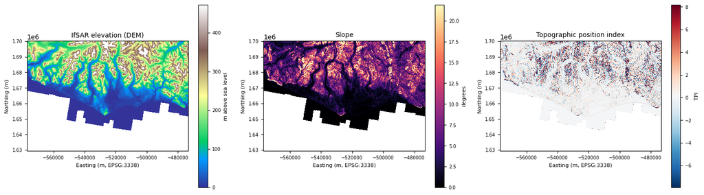

```python
fig, axes = plt.subplots(1, 3, figsize=(15, 5))
panel(axes[0], RM / "ifsar_dem_district_3338.tif",
      "IfSAR elevation (DEM)", "m above sea level", cmap="terrain")
panel(axes[1], RM / "ifsar_slope_district_3338.tif",
      "Slope", "degrees", cmap="magma")
panel(axes[2], RM / "ifsar_tpi_district_3338.tif",
      "Topographic position index", "TPI", cmap="RdBu_r")
plt.tight_layout()
```

**What it is.** The Interferometric Synthetic Aperture Radar (IfSAR) digital elevation model is Alaska’s statewide 5 m radar elevation surface. Slope and the topographic-position index (how high a cell sits relative to its surroundings) are derived from it.

**What it is for.** Terrain is the backbone of the placer model: the beaches, benches, and creek bottoms where placer gold concentrates have distinct elevation and slope signatures. It is also the feature that made the first lode model lie, because in a small box the lodes sit up in the schist hills and the background sits down on the coastal flat, so a model can separate them on elevation alone and never learn any geology. That trap is the subject of the lode-results section below.

**How the model reads it.** Elevation, slope, and topographic position enter both models directly as per-cell covariates.

### Geology: Nome Group units and the graphitic host

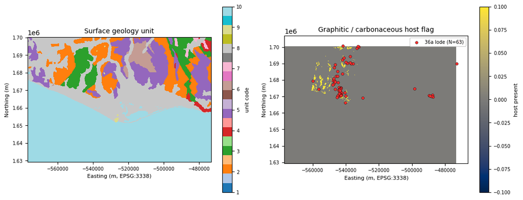

```python
fig, axes = plt.subplots(1, 2, figsize=(11, 5))
lodes = lode_36a()
panel(axes[0], NP / "covariates_mpm" / "geology_unit_code_district_3338.tif",
      "Surface geology unit", "unit code", cmap="tab20",
      categorical=True, mask_neg=True)
panel(axes[1], STRUCT / "struct_carbonaceous_host.tif",
      "Graphitic / carbonaceous host flag", "host present", cmap="cividis",
      points=lodes, plabel="36a lode")
plt.tight_layout()
```

**What it is.** The surface-geology unit at each cell, and a flag for the graphitic (carbon-rich) schists of the Nome Group. The units come from the statewide compilation; the graphitic-host flag comes from the detailed Alaska state maps of the Seward Peninsula bedrock (DGGS SIM 3131 for the Nome and Solomon quadrangles, RI 2024-7 for Casadepaga), which label the carbonaceous units explicitly.

**What it is for.** The Nome Group schists are the reactive host rock for the gold-quartz veins. Orogenic gold of this type favors carbon-rich units, the reactive-host control Groves et al. describe; the usual explanation is that the wall-rock chemistry helps precipitate gold from solution. The 36a lode occurrences (red) cluster on and near the graphitic ground.

**How the model reads it.** The geology unit enters as a set of one-hot indicator columns; the graphitic-host flag enters as its own binary covariate.

### Structure: the fault sets, the named faults, and the Groves features

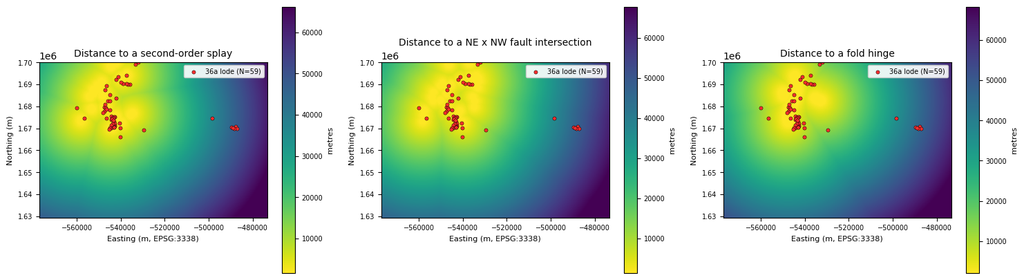

```python
fig, axes = plt.subplots(1, 3, figsize=(15, 5))
ext = None
for ax, fn, title in [
    (axes[0], "struct_dist_splay.tif", "Distance to a second-order splay"),
    (axes[1], "struct_dist_fault_intersection.tif", "Distance to a NE x NW fault intersection"),
    (axes[2], "struct_dist_fold_hinge.tif", "Distance to a fold hinge"),
]:
    arr, ext = panel(ax, STRUCT / fn, title, "metres", cmap="viridis_r")
lodes = lode_36a(ext)
for ax in axes:
    ax.scatter(lodes.geometry.x, lodes.geometry.y, s=14, c="#ff2d2d",
               edgecolor="black", linewidth=0.35, label=f"36a lode (N={len(lodes)})")
    ax.legend(loc="upper right", fontsize=7, framealpha=0.9)
plt.tight_layout()
```

**What it is.** Three structural-distance fields, brighter where the structure is nearer. A second-order **splay** is a small fault branching off a main fault trunk; an **intersection** is where a northeast-trending fault crosses a northwest-trending one; a **fold hinge** is the axis where folded rock layers bend. All three are read from the most detailed public structural map of the district, the Alaska state GeMS geodatabase for the Nome mining district (DGGS PDF 94-39), which also names the district faults: Anvil, Penny River, Aurora Creek, Charlie Creek, Boulder Creek, Rodine.

**What it is for.** This is the lode model’s centerpiece. Distance to the nearest big fault, the obvious feature, is the wrong one for orogenic gold. Groves and coauthors showed across many districts that the gold does not sit on the fault trunks; it sits in the second-order splays, at the intersection nodes, and near fold hinges, inside the reactive host. Building those controls directly, rather than distance-to-any-fault, is what separated the rebuilt lode model from the failed first version.

**How the model reads it.** Splay proximity, intersection proximity, and fold-hinge distance enter as three covariates. The results section shows that these are the three features the model leans on hardest, ahead of any individual named fault.

### Geophysics: aeromagnetics and 1993 airborne resistivity

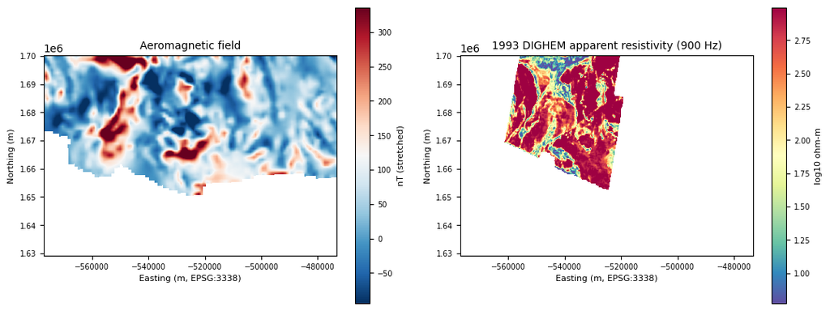

```python
fig, axes = plt.subplots(1, 2, figsize=(11, 5))
panel(axes[0], NP / "covariates_mpm" / "akmag_district_3338.tif",
      "Aeromagnetic field", "nT (stretched)", cmap="RdBu_r")
panel(axes[1], NG / "dighem1993" / "district_100m" / "dighem_res_log10_900hz.tif",
      "1993 DIGHEM apparent resistivity (900 Hz)", "log10 ohm-m", cmap="Spectral_r")
plt.tight_layout()
```

**What it is.** The regional aeromagnetic field (magnetic susceptibility of the rocks) and the 1993 Nome DIGHEM-V helicopter electromagnetic survey (DGGS GPR 2019-11, 400 m flight lines), reduced to apparent electrical resistivity. The resistivity covers only the flown strip, so much of the district is blank.

An expected cross-check also failed. The graphitic units, predicted to read as electrical conductors (a *low* apparent resistivity, the alteration signature the literature looks for), instead read as more resistive than their surroundings: median apparent resistivity about 0.3 to 0.8 log10 ohm-m higher across the 900 Hz, 7.2 kHz, and 56 kHz channels. We did not test why. One untested possibility is that a 400 m airborne EM survey over permafrost terrain does not resolve deep graphite, but we cannot cite that, so it is a hypothesis, not a finding. Either way the host flag earns its place as a map-geology covariate, not as a geophysical conductor.

**What we did not build.** We tested these layers one at a time. We did not construct the combined alteration index the literature advocates (low magnetic susceptibility with low apparent resistivity and a localized gravity low, read together as a proxy for a buried hydrothermal center), and gravity is not in the Nome stack at all. The geophysics result here is a limit of what we built, not a refutation of that index.

**How the model reads it.** The statewide aeromagnetic field enters the served lode model as a base covariate, where it ranks low in feature importance; on placer it is negative. The DIGHEM survey and gravity are not in the served surfaces.

### Placer layers: the strandlines, the populations, and the LiDAR

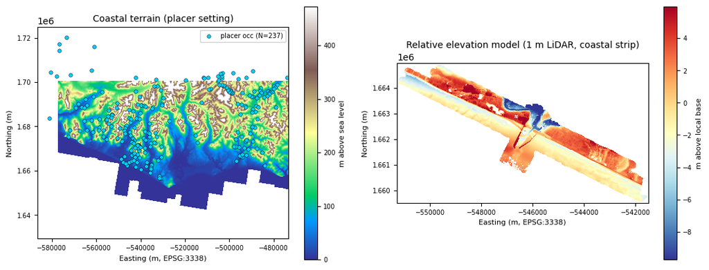

```python
fig, axes = plt.subplots(1, 2, figsize=(11, 5))
placers = placer_occ()
panel(axes[0], RM / "ifsar_dem_district_3338.tif",
      "Coastal terrain (placer setting)", "m above sea level",
      cmap="terrain", points=placers, plabel="placer occ", pcolor="#00d0ff")
panel(axes[1], NP / "beachline_rem" / "rem.tif",
      "Relative elevation model (1 m LiDAR, coastal strip)",
      "m above local base", cmap="RdYlBu_r")
plt.tight_layout()
```

**What it is.** The coastal terrain with the placer occurrences on it (left), and a relative elevation model (right) built from the 2021 NOAA/USACE 1 m bare-earth LiDAR, which detrends the regional slope to make low relief stand out. The Nome placers sit on a stack of raised and submerged paleo-shorelines: the Second Beach at about +38 ft, the Third Beach at +70 ft (the high-grade exemplar), the Fourth at +120 ft, and several submerged stands offshore.

**What it is for.** These layers encode where the gold-bearing beaches and their reworked stream placers are. The placer model is, in effect, a beach-line model already: its existing features score nearness to a true beach-stand elevation, the abrasion platforms, and the buried beach lines. A round-2 test added the 1 m LiDAR strandline geometry and found it added nothing measurable over that existing backbone, which says the beach-line geometry was the model’s spine all along. The 1 m LiDAR’s real value is berm-scale targeting on a single claim, not district-scale ranking.

**How the model reads it.** The placer model carries explicit geomorphic population features (beach, abrasion platform, buried beach, stream reworking) on top of the terrain stack.

### Labels: the typed lode set and the placer occurrences

```
36a lode occurrences shown: 59   placer occurrences shown: 210
```

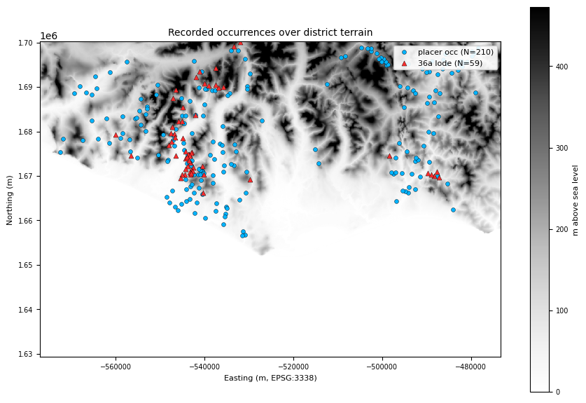

```python
fig, ax = plt.subplots(figsize=(9, 7))
arr, ext = panel(ax, RM / "ifsar_dem_district_3338.tif",
                 "Recorded occurrences over district terrain",
                 "m above sea level", cmap="Greys")
lo = lode_36a(ext); pl = placer_occ(ext)
ax.scatter(pl.geometry.x, pl.geometry.y, s=18, c="#00b3ff", edgecolor="black",
           linewidth=0.3, label=f"placer occ (N={len(pl)})")
ax.scatter(lo.geometry.x, lo.geometry.y, s=26, c="#ff2d2d", edgecolor="black",
           linewidth=0.3, marker="^", label=f"36a lode (N={len(lo)})")
ax.legend(loc="upper right", fontsize=8, framealpha=0.9)
plt.tight_layout()
print(f"36a lode occurrences shown: {len(lo)}   placer occurrences shown: {len(pl)}")
```

**What it is.** The training labels. The lode positives are the ARDF occurrences the USGS classifies as Cox-Singer model `36a`, low-sulfide gold-quartz vein, the deposit type the Nome lodes actually are. The placer positives are the ARDF placer occurrences inside the area of interest.

**How the model reads it.** Positives are the occurrence cells; negatives are a background sample of the district. No occurrence-derived feature is allowed to leak the label, which is the subject of the next section.

## How the algorithm consumes the data

The covariates above feed a random forest (300 trees, class-balanced, fixed seed), but the modeling choice that decides whether the numbers mean anything is the cross-validation, not the estimator.

```python
sc = boot["scheme"]
print("Leak-guarded spatial cross-validation:")
print(f"  fold strategy     : {sc['fold_strategy']} regions")
print(f"  number of folds   : {sc['n_folds']}")
print(f"  block size        : {sc['block_size_m']:.0f} m  "
      f"(2x the {sc['variogram_range_m']:.0f} m residual-variogram range)")
print(f"  dead-zone buffer  : {sc['dead_zone_m']:.0f} m around every held-out point")
```

```
Leak-guarded spatial cross-validation:
  fold strategy     : contiguous regions
  number of folds   : 10
  block size        : 3800 m  (2x the 1879 m residual-variogram range)
  dead-zone buffer  : 1000 m around every held-out point
```

**Spatial blocks, not random folds.** Occurrences cluster, and nearby cells share terrain, so a random train/test split lets the model score a test point off its own near-neighbor in training. The folds here are contiguous regions, sized from the range of spatial autocorrelation in the model’s own residuals (a variogram fit), so a held-out block is large enough to be genuinely independent of the training ground.

**A dead-zone around every test point.** On top of the block split, any training cell within 1 km of a held-out occurrence is dropped, which is wider than the few-hundred-meter proximity buffers in the structural features. A test point cannot be scored by a training neighbor sitting just across the fold line.

**The leakage lesson.** An earlier experiment rasterized the knowledge graph’s occurrence-derived features onto the grid and saw the lode AUC jump toward 0.97. That gain was a coverage artifact: the features and the labels were drawn from one occurrence inventory, so a cell’s own record was informing its own prediction. Under a fold-aware leave-one-out, where each held-out cell’s own record is removed from the feature set, the gain collapsed to roughly zero. Any feature derived from the occurrence inventory is treated as guilty until cleared.

**Refit-on-all for the served map.** The AUC numbers are held-out estimates of the pipeline’s skill. The surface that gets served is the same pipeline refit on all the labels, so it uses every occurrence to draw the best map it can. The reported AUC describes the method’s skill, not a property of the all-data refit, and the two are kept distinct.

## Results

### The lode prospectivity surface

```
served cells: 142,215   value range: [0.000, 0.930]
median: 0.007   p90: 0.083   p99: 0.407
```

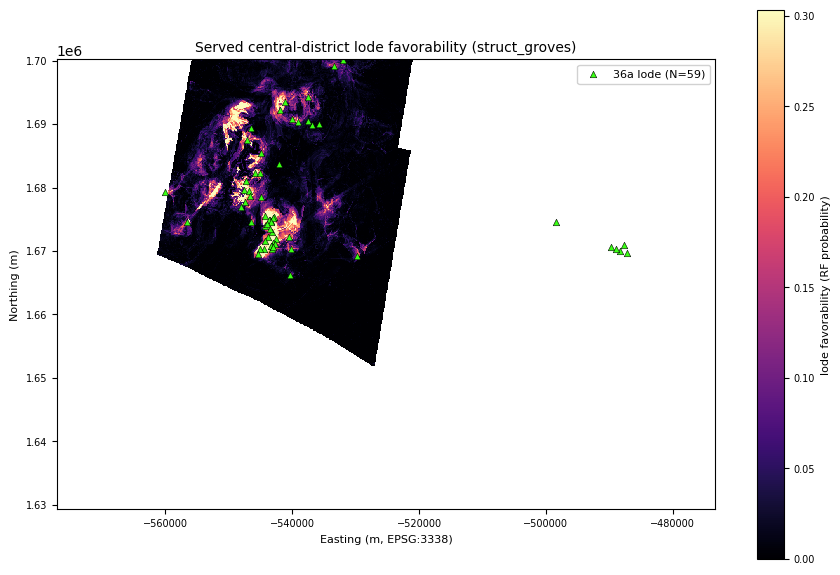

```python
fig, ax = plt.subplots(figsize=(9, 7))
arr, ext = panel(ax, LODE_SERVED,
                 "Served central-district lode favorability (struct_groves)",
                 "lode favorability (RF probability)", cmap="magma",
                 mask_neg=True)
lo = lode_36a(ext)
ax.scatter(lo.geometry.x, lo.geometry.y, s=22, c="#39ff14", edgecolor="black",
           linewidth=0.4, marker="^", label=f"36a lode (N={len(lo)})")
ax.legend(loc="upper right", fontsize=8, framealpha=0.9)
plt.tight_layout()

v = arr[np.isfinite(arr)]
print(f"served cells: {v.size:,}   value range: [{v.min():.3f}, {v.max():.3f}]")
print(f"median: {np.median(v):.3f}   p90: {np.percentile(v,90):.3f}   "
      f"p99: {np.percentile(v,99):.3f}")
```

The served surface is masked to the GeMS-mapped footprint, the only ground where the splay and intersection features are defined; outside it the favorability is not meaningful, so it is left blank. The typed lode occurrences (green) land on the high-favorability ground.

### Feature importance: the Groves controls lead, ahead of the named faults

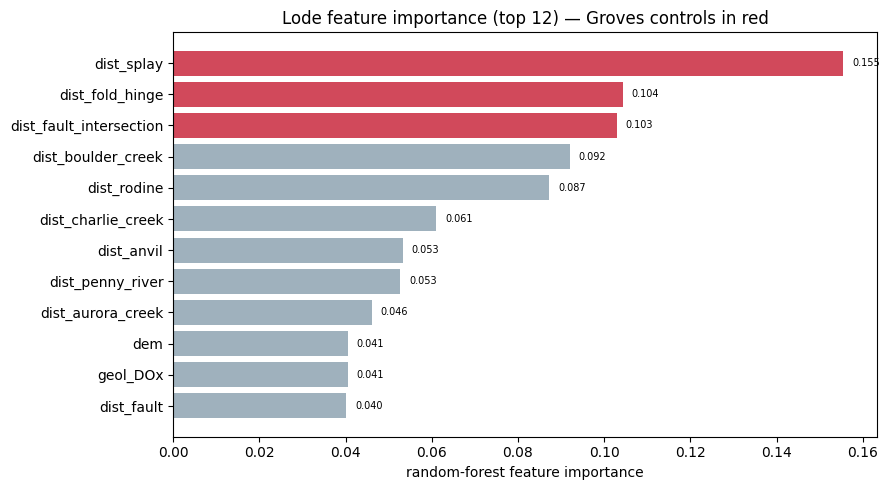

```python
fi = gate["datasets"][0]["feature_importance_sharp_all_top12"]
names = [f[0] for f in fi][::-1]
imp = [f[1] for f in fi][::-1]
groves_feats = {"dist_splay", "dist_fault_intersection", "dist_fold_hinge"}
colors = ["#d1495b" if n in groves_feats else "#9fb1bd" for n in names]

fig, ax = plt.subplots(figsize=(9, 5))
ax.barh(names, imp, color=colors)
ax.set_xlabel("random-forest feature importance")
ax.set_title("Lode feature importance (top 12) — Groves controls in red")
for i, (n, v) in enumerate(zip(names, imp)):
    ax.text(v + 0.002, i, f"{v:.3f}", va="center", fontsize=7)
plt.tight_layout()
```

The three Groves controls, splay proximity, fold-hinge distance, and fault-intersection proximity, rank as the top three features, ahead of every individually named fault and ahead of elevation. The structural law the first model failed to find was real; the first model had the wrong features for it.

### The lode mirage: restriction of range, and the fix

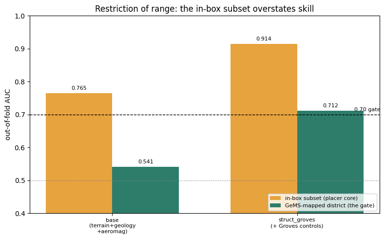

```python
arms = gate["datasets"][0]["arms"]
groups = ["base\n(terrain+geology\n+aeromag)", "struct_groves\n(+ Groves controls)"]
inbox = [arms["base"]["auc_placer_core"], arms["struct_groves"]["auc_placer_core"]]
district = [arms["base"]["auc_gems"], arms["struct_groves"]["auc_gems"]]

x = np.arange(len(groups)); w = 0.36
fig, ax = plt.subplots(figsize=(8, 5))
b1 = ax.bar(x - w/2, inbox, w, label="in-box subset (placer core)", color="#e7a33e")
b2 = ax.bar(x + w/2, district, w, label="GeMS-mapped district (the gate)", color="#2e7d6b")
ax.axhline(0.70, color="black", ls="--", lw=1)
ax.text(1.45, 0.71, "0.70 gate", fontsize=8, ha="right")
ax.axhline(0.5, color="gray", ls=":", lw=1)
ax.set_xticks(x); ax.set_xticklabels(groups, fontsize=8)
ax.set_ylabel("out-of-fold AUC"); ax.set_ylim(0.4, 1.0)
ax.set_title("Restriction of range: the in-box subset overstates skill")
for bars in (b1, b2):
    for r in bars:
        ax.text(r.get_x()+r.get_width()/2, r.get_height()+0.01,
                f"{r.get_height():.3f}", ha="center", fontsize=8)
ax.legend(fontsize=8, loc="lower right")
plt.tight_layout()
```

The in-box subset (the small box around the placer core) reads high for every model, because inside it the lodes are upland schist and the background is coastal flat. That is restriction of range: the model separates the classes on the box geometry, not the geology. The GeMS-mapped district AUC is the gate that strips the geometry out. The first keyword-labeled lode model scored about `0.80` in the small box and fell to `0.58` across the district, and for a while that collapse was the chapter’s negative result. The rebuild, typed dispersed labels plus the Groves controls, brought the district number to `0.712`, a `+0.170` gain over the same model without the structure features, with a paired bootstrap 95% interval of `+0.108` to `+0.234` that clears zero.

### The peninsula generalization

```
held-out east gain over base: +0.104  95% CI [-0.073, +0.282] (crosses zero)
```

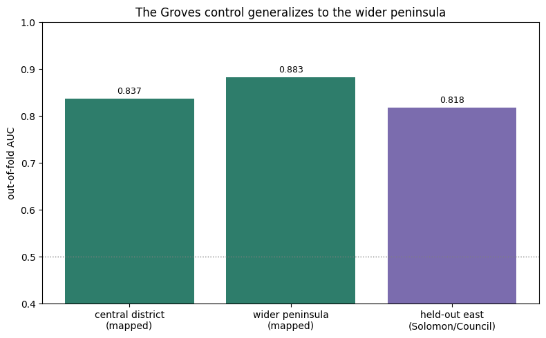

```python
pen = load_json(NP / "lode_peninsula_generalization" / "lode_peninsula_generalization.json")
cen = pen["central_matched"]["arms"]["struct_groves"]
wid = pen["wider"]["arms"]["struct_groves"]
east_ci = wid["bootstrap_east"]["ci95"]

bars = {
    "central district\n(mapped)": cen["auc_mapped"],
    "wider peninsula\n(mapped)": wid["auc_mapped"],
    "held-out east\n(Solomon/Council)": wid["auc_east"],
}
fig, ax = plt.subplots(figsize=(8, 5))
cols = ["#2e7d6b", "#2e7d6b", "#7b6cae"]
b = ax.bar(list(bars), list(bars.values()), color=cols)
ax.axhline(0.5, color="gray", ls=":", lw=1)
ax.set_ylabel("out-of-fold AUC"); ax.set_ylim(0.4, 1.0)
ax.set_title("The Groves control generalizes to the wider peninsula")
for r in b:
    ax.text(r.get_x()+r.get_width()/2, r.get_height()+0.01,
            f"{r.get_height():.3f}", ha="center", fontsize=9)
plt.tight_layout()
print(f"held-out east gain over base: +{wid['d_auc_east']:.3f}  "
      f"95% CI [{east_ci[0]:+.3f}, {east_ci[1]:+.3f}] (crosses zero)")
```

Rebuilt on regional bedrock maps and scored on lode occurrences dispersed across the whole Seward Peninsula, the same splay-intersection-fold-host signal predicts lodes at about `0.88` on the mapped ground, and at `0.82` on an eastern cluster around Solomon and Council that the central model never trained on. The control is not a central-district artifact.

A round-4 retest pinned down which part of that eastern signal travels. With the eastern label set expanded by disciplined typing (eleven 36a positives, up from nine) and the structure features split into two arms scored against the same lithology-and-fault base, the orientation arm, which resolves fault proximity into the northeast and northwest fault sets, gains `+0.119` over the base in the east (95% CI `-0.008` to `+0.269`). The Groves refinement arm, which instead carries splay and fault-intersection proximity, does not travel: in the east it moves the AUC by `-0.047` over the base, a 95% CI of `-0.189` to `+0.096` that spans zero. On the mapped ground that same refinement is strongly positive (`+0.161`, CI `+0.093` to `+0.227` in the central district; `+0.380`, CI `+0.302` to `+0.457` across the peninsula). The reading is that fault orientation is the part of the structural law that generalizes east, while the splay-and-intersection refinement is tuned to the Nome district where it was built. That is why the central-district surface is the served result and the peninsula extension is reported as validated but provisional.

### The placer surface and the beach-line backbone

```
placer spatial-CV AUC: 0.733   buffered: 0.741   beach-line overlay: 0.444
```

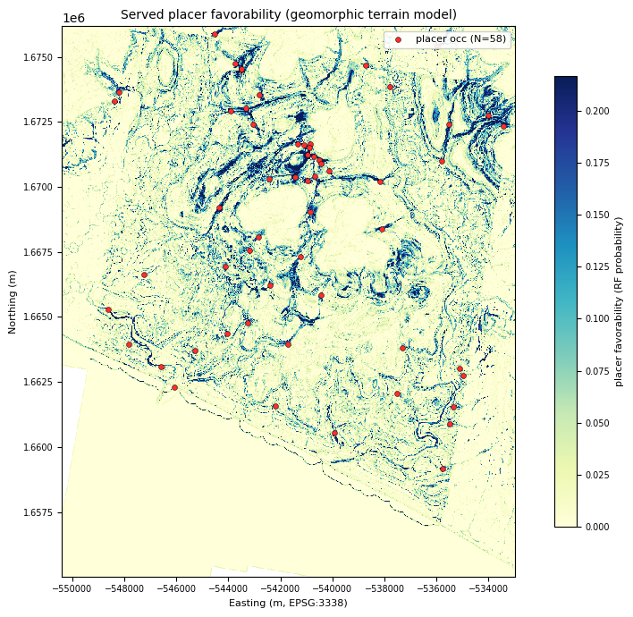

```python
fig, ax = plt.subplots(figsize=(9, 7))
arr, ext = panel(ax, PLACER_SERVED,
                 "Served placer favorability (geomorphic terrain model)",
                 "placer favorability (RF probability)", cmap="YlGnBu",
                 mask_neg=True)
pl = placer_occ(ext)
ax.scatter(pl.geometry.x, pl.geometry.y, s=18, c="#ff2d2d", edgecolor="black",
           linewidth=0.35, label=f"placer occ (N={len(pl)})")
ax.legend(loc="upper right", fontsize=8, framealpha=0.9)
plt.tight_layout()
print(f"placer spatial-CV AUC: {placer['mpm_geomorph_terrain_spatialCV_auc']:.3f}   "
      f"buffered: {placer['mpm_geomorph_terrain_buffered300m_auc']:.3f}   "
      f"beach-line overlay: {placer['baseline_v31_composite_auc']:.3f}")
```

## Findings

**The same Nome Group veins source both maps.** The lode targets are the fractured quartz-sulfide veins in the Nome Group schist; the placer gold is what weathered out of those veins and was carried down. The genesis the literature lays out is a three-stage system (the 1978 Alaska DGGS study of the Nome coastal and offshore placers): glaciers stripped the mineralized bedrock and dumped unsorted, low-grade till (about 70 ppb gold) across the coastal shelf; marine transgressions then winnowed the fine matrix out of that drift, leaving dense gold concentrated on a stack of raised and submerged beach lines; late-stage streams cut across those beaches and re-sorted them into the bonanza pay, Anvil Creek dissecting the Third Beach being the type example. That is why the placer model is a beach-line model and why the richest ground sits where streams cross old shorelines.

**The negative results are signal too.** Several things that looked promising did not survive the ruler, and each one rules out a feature so the next round does not re-try it:

- Splitting the faults out by name **hurt** the lode model (the per-named-fault arm scored `0.422` against the lumped Groves arm’s `0.712`). Orientation and structural role beat fault identity.
- The deposit-scale Albion fault at Rock Creek was **redundant** once the splay and intersection bands were in (it moved the AUC by `-0.021`, within noise).
- The drift-on-beach lever is a **tested null**. The raised-beach model holds that gold concentrates where a strandline crosses gold-bearing glacial drift. The most precise Nome-town surficial map (USGS MF-247) maps the coastal plain as one undifferentiated unit, so the one digitizable line is the bedrock/Quaternary contact, a proxy for the drift’s inland edge. As a covariate it adds nothing over the beach-line base (strandline-crossing marginal AUC `-0.030`, 95% CI `-0.072` to `+0.011`), and the positives sit a median 1.6 km seaward of the contact. Whatever the drift contributes is already inside the beach-line score. This is a null for the proxy, not a refutation of the mechanism: a discrete central-Nome drift polygon, if one is ever digitized, could still carry more.
- **Typing the placer positives by coastal population was a null, set by sample size.** Only 8 of the 65 recorded placer occurrences are cleanly typed as coastal beaches (5 abrasion-platform, 3 strandline, after Hudson 2006 and Metcalfe & Tuck 1942); the other 57 are upland stream-and-gulch placers or district-wide composites. Both coastal types sit farther from the lodes than the district background, not nearer, and the two are indistinguishable on every local-source covariate tested (every rank `p >= 0.29` at n = 5 versus 3). The one direction matching the local-source hypothesis, abrasion-platform sitting nearer the lode-belt axis than strandline, does not reach significance (`p = 0.11`). The real local-source structure is the upland placers sitting on their own lodes (median 1.4 km), which is partly circular and already captured by terrain, so the pooled model gains nothing from a distance-to-lode feature (`+0.026`, CI `-0.020` to `+0.071`). A powered retest needs a positive set with more typed coastal beaches: the Metcalfe & Tuck paystreak inventory or the NovaGold drill database.
- The 400 m **aeromagnetics carried no independent lode signal** on the flown cells (marginal AUC about -0.02 to -0.06). The DIGHEM **apparent resistivity** helped a little at district scale (about +0.03) but not in the central box, and neither DIGHEM layer is in the served surface. The predicted graphitic-conductor cross-check failed the other way: the graphitic units read as more resistive, not less. We did not build the combined low-magnetic / low-resistivity / gravity-low alteration index the literature advocates, so this is a limitation, not a refutation.

**What each layer contributed.** Terrain carries the placer model and set the trap for the first lode model. Geology supplies the host. Structure, specifically the Groves splay/intersection/fold features, is what moved the lode from chance to a real number. Of the geophysics, the magnetics did not help and the resistivity helped only marginally; structure, not geophysics, carries the lode. The typed `36a` labels were half the lode fix, the Groves features the other half.

## Files and reproduction

- Served lode surface: scripts/nome_placer/mpm_lode_score_district.py
- Served placer surface: scripts/nome_placer/mpm_onshore_score_district.py
- Lode gate (typed 36a, Groves arms): scripts/nome_placer/lode_structure_sharpen_cv.py
- Bootstrap CI on the gain: scripts/nome_placer/lode_groves_bootstrap.py
- Peninsula generalization: scripts/nome_placer/lode_peninsula_generalization.py
- Eastern-splay orientation-vs-refinement retest: scripts/nome_placer/lode_eastern_splay_confirm.py
- Drift-on-beach bedrock-contact proxy: scripts/nome_placer/placer_bedrock_contact_cv.py
- Placer subtype local-source test: scripts/nome_placer/placer_subtype_local_source.py
- Structure feature builders: src/ai_minerals/data/nome_structure.py
- Aeromagnetic / DIGHEM loader: src/ai_minerals/data/dighem.py
- Placer LiDAR / strandlines: src/ai_minerals/data/nome_placer_rem.py
- Leak-guarded CV harness: src/ai_minerals/spatial_cv.py
- The public chapter this sits behind: portfolio/nome_placer.qmd

## Sources

- USGS, Alaska Resource Data File (ARDF): occurrence records and Cox-Singer deposit-type codes.
- Alaska DGGS, Geologic Materials (GeMS) database for the Nome mining district, PDF 94-39: faults, named structures, fold axes, graphitic units.
- Alaska DGGS, SIM 3131 (Nome and Solomon quadrangle bedrock) and RI 2024-7 (Casadepaga): regional structure and graphitic host for the peninsula test.
- Alaska DGGS, GPR 2019-11: the 1993 Nome DIGHEM-V airborne electromagnetic and magnetic survey.
- USGS, MF-247 (Hummel, 1962): surficial geology of the Nome C-1 quadrangle, the bedrock/Quaternary contact for the drift-on-beach proxy.
- Hudson (2006) and Metcalfe & Tuck (1942): the Nome placer populations (abrasion-platform versus strandline-beach) and the paystreak inventory behind the subtype typing.
- USGS, gridded aeromagnetic data for Alaska.
- Alaska statewide IfSAR 5 m digital elevation model.
- NOAA / USACE, 2021 Nome 1 m topobathymetric LiDAR.
- Alaska DGGS, Deposition Dynamics, Stratigraphy, and Economic Geology of the Nome Coastal and Offshore Placer Gold Deposits, Seward Peninsula, Alaska (1978): the placer genesis.
- Groves et al., on the structural controls of orogenic gold (splays, intersections, fold hinges, reactive hosts). ```